# swirl

## 3. Regression Models: The basics of regression modeling in R

**Intermediate**: The basics of regression modeling in R

## 4. Statistical Inference: The basics of statistical inference in R

**Advanced**

This intermediate to advanced level course closely follows the Statistical Inference course of the Johns Hopkins Data Science Specialization on Coursera. It introduces the student to basic concepts of statistical inference including probability, hypothesis testing, confidence intervals and p-values. It concludes with an initiation to topics of particular relevance to big data, issues of multiple testing and resampling.

## 5. Exploratory Data Analysis: The basics of exploring data in R

## 6. Other Courses

- [Swirl Courses Organized by Title](http://swirlstats.com/scn/title.html)
- [Swirl Courses Organized by Author’s Name](http://swirlstats.com/scn/surname.html)
- [Github: swirl courses](https://github.com/swirldev/swirl_courses#swirl-courses) のコースの説明を参照してください。

### 6.1 The R Programming Environment

> Roger Peng
- **Beginner**
- The first course in the Mastering Software Development in R series
- [Github: swirldev/The_R_Programming_Environment](https://github.com/swirldev/The_R_Programming_Environment)
- `swirl::install_course("The R Programming Environment")`

### 6.2 Getting and Cleaning Data

**Inermediate** dplyr, tidyr, lubridate, oh my!

### 6.3 Advanced R Programming

**Advanced**

### 6.4 A (very) short introduction to R

#### 6.4.1 この Swirl について

> [Claudia Brauer (Wageningen University)](https://www.vcard.wur.nl/Views/Profile/View.aspx?id=9028&ln=eng) が同僚の Paul Torfs と協力して作成した、swirl です。大学で、Windows User を、主として対象として、説明がなされていますが、むろん、Mac でも、大学生でなくても、使えます。ただし、大学入学年や、誕生日を入力したり、一カ所、毎年12月5日にプレゼントを送る習慣のある、オランダのお祭りSinterklaasの言及があります。

> 特徴の一つは、[CRAN にある同名の2014年の文書](https://cran.r-project.org/doc/contrib/Torfs+Brauer-Short-R-Intro.pdf)の実践編として、作られていることです。もう一つは、下の、Github のリンクをみるとわかりますが、全部で、8つの Module に別れており、そのうちの、Module 1 から Module 3 が swirl に収録されていますが、それ以後も、Self-Study Module として公開されています。Module 4. Basic plotting, 5. Pretty plotting, 6. Reading data files, 7. Matrix operations, 8. Spatial data. Massive Open Online Course の一つの形式になっています。

> 2018年ごろにできたばかりとしてあり、たしかに、要求された答えと異なるときの、挙動に多少問題があるように、思われるが、完璧を期さず、そのときは、skip() として、答えをみるのも良いだろう。わたしも、二度、skip() を使うこととなった。一カ所は、matrix の箇所、もう一つは、最後の問題。後者は、わたしの、単純な見落としである。
- Github: ClaudiaBrauer/A-very-short-introduction-to-R, 2018年版の PDF や、Swirl がはじめての人のための紹介もあります。
- Script にもあるように、`swirl::install_course("A_(very)_short_introduction_to_R")` によって、Install して使います。

> 以下、つまづきそうな箇所のみコメントを加えます。

#### 6.4.1 Install から Module の選択まで

最初には、swirl を使うよという宣言 `library(swirl)` です。swirl が読み込まれます。

```
> library(swirl)

| Hi! I see that you have some variables saved in your workspace. To keep things running
| smoothly, I recommend you clean up before starting swirl.

| Type ls() to see a list of the variables in your workspace. Then, type rm(list=ls()) to
| clear your workspace.

| Type swirl() when you are ready to begin.
```

次の、コマンドで、この swirl を Install します。

```
> swirl::install_course("A_(very)_short_introduction_to_R")
  |=================================================================================| 100%

| Course installed successfully!
```

swirl のスタートは、常に、この命令 `swirl()` です。

```
> swirl()

| Welcome to swirl! Please sign in. If you've been here before, use the same name as you
| did then. If you are new, call yourself something unique.

What shall I call you? SL
```

コースを選択します。1 がこのコース、2 は、最初に紹介している、swirl の基本なコースです。

```
| Please choose a course, or type 0 to exit swirl.

1: A (very) short introduction to R
2: R Programming
3: Take me to the swirl course repository!

Selection: 1

| Please choose a lesson, or type 0 to return to course menu.

1: Module 1
2: Module 2
3: Module 3

Selection: 1
```

#### 6.4.2 Module 1

```
| This is the first module of the course `A (very) short introduction to R`. This course
| is based on a non-interactive tutorial with the same name, which can be downloaded from
| www.github.com/ClaudiaBrauer/A-very-short-introduction-to-R. The contents are the same
| (with a few exceptions), so you can open the pdf version alongside to look up how to do
| something you learned before or browse through the references on the last two pages.

...
```

このマーク … が出たら、そこまで読んで、Enter でした。

```
| This swirl course is brand new, so it may still contain errors. If you find any, let me
| know on the issues page of the github-website.

...
```

まだ、できたてなので、エラーがあるかもしれないと断ってあります。 しばらくは、pdf になっている、文書にそった、説明がなされます。RStudio の説明もなされており、pdf で読むより、実際に確認できるので、よいでしょう。

```
| Now, let's get started.

...

| The RStudio interface consists of several windows. You can change the size of the
| windows by dragging the grey bars between the windows.

...

| Bottom left is the console window (also called command window/line). Here you can type
| commands after the > prompt and R will then execute your command. This is the most
| important window, because this is where R actually does stuff.

...

| Top left is the editor window (also called script window). Here collections of commands
| (scripts) can be edited and saved. When you do not get this window, you can open it with
| 'File' > 'New' > 'R script'. Just typing a command in the editor window is not enough,
| it has to get into the command window before R executes the command. If you want to run
| a line from the script window (or the whole script), you can click 'Run' or press
| 'CTRL+ENTER' to send it to the command window.

...

| Top right is the workspace / history window. In the workspace window you can see which
| data and values R has in its memory. You can view and edit the values by clicking on
| them. The history window shows what has been typed before.

...

| Bottom right is the files / plots / packages / help / viewer window. Here you can open
| files, view plots (also previous plots), install and load packages or use the help
| function.

...

| Your working directory is the folder on your computer in which you are currently
| working. When you ask R to open a certain file, it will look in the working directory
| for this file, and when you tell R to save a data file or figure, it will save it in the
| working directory.

...

| Before you start working, you should set your working directory to where all your data
| and script files are or should be stored. Within RStudio you can go to 'Session' > 'Set
| working directory' > 'Choose directory'. Please do this now.

...

| Instead of clicking, you can also type in the command window setwd("directoryname"). For
| example setwd("M:/Hydrology/R/") . Make sure that the slashes are forward slashes and
| that you do not forget the apostrophes (for the reason of the apostrophes, see Module 3.
| R is case sensitive, so make sure you write capitals where necessary. You don't have to
| try this now.

...
```

R Programming のコースの、第2課（2.2 Workspace and Files）で説明してあります。`getwd()` とすると、現在の作業ディレクトリがわかります。`setwd()` で指定します。説明にあるように、RStudio では、メニューの、‘Session’ > ‘Set’ > working directory’ > ‘Choose directory’ でも設定できます。そこに新しいファイルを作ります。あとで、それを、swirl という名前せよ、となりますから、最初から、swirl というディレクトリーをつくって、それを、Working Directory にしておくとよいでしょう。

```
| R can do many statistical and data analyses. They are organized in so-called packages or
| libraries. With the standard installation, most common packages are installed.

...

| To get a list of all installed packages, go to the packages window. If the box in front
| of the package name is ticked, the package is loaded (activated) and can be used. Look
| up the swirl package in the packages window and see if the box is checked.

...

| There are many more packages available on the R website. If you want to install and use
| a package (for example, the package called 'geometry') you should first install the
| package by clicking 'install packages' in the packages window and typing geometry or by
| typing install.packages("geometry") in the command window. You actually already did this
| for the swirl package.

...

| Next, you should load the package by checking box in front of geometry or typing
| library(geometry) in the command window. You also did this for the swirl package
| (otherwise you couldn't have been doing these exercises).

...

| Now, let's get started with the real programming.

...
```

ここから実際の演習が始まります。最初は、`10^2 + 36` です。`10^2` は 10の二乗、$10^2 = 10\times 10$ の事です。

```
| R can be used as a calculator. You can just type your equation in the command window
| after the >. Type 10^2 + 36.
```

```r
10^2 + 36
```

```
## [1] 136
```

```
| You are quite good my friend!

| And R gave the answer directly. By the way, spaces do not matter.

...

| Compute the difference between 2019 and the year you started at this university and
| divide this by the difference between 2019 and the year you were born. Multiply this
| with 100 to get the percentage of your life you have spent at this university. Use
| brackets if you need them.
```

すこし面倒なことを言っていますが、なにか入力してください。2019年が想定されています。 ```

```r
(2019-2017)/(2019-1999)
```

```
## [1] 0.1
```

```
| All that practice is paying off!

| If you use brackets and forget to add the closing bracket, the > on the command line
| changes into a +. The + can also mean that R is still busy with some heavy computation.
| If you want R to quit what it was doing and give back the >, press ESC (see the
| reference list on the last page of `A (very) short introduction to R`).

...

| You can also give numbers a name. By doing so, they become so-called variables which can
| be used later. For example, you can type in the command window A = 4 .
```

```r
A = 4
```

```
| You got it!

| You can see that A appeared in the workspace window in the top right corner, which means
| that R now remembers what A is.

...
```

ここでは、workspace window とありますが、RStudio の右上の pane の Environment Tab を選択するとそのとき保存されている変数などが出てきます。これを時々確認するのは有効です。

```
| Some people prefer te use <- instead of =. They do the same thing. <- consists of two
| characters, namely < and -, and represents an arrow pointing at the object receiving the
| value of the expression.

...

| You can also ask R what A is. Just type A in the command window.
```

```r
A
```

```
## [1] 4
```

```
| You nailed it! Good job!

| You can also do calculations with A. Type A * 5 .
```

```r
A * 5
```

```
## [1] 20
```

```
| You are amazing!

| If you specify A again, it will forget what value it had before. You can also assign a
| new value to A using the old one. Type A = A + 10 .
```

```r
A = A + 10
```

```
| Excellent work!

| You can see that the value in the workspace window changed.

...

| To remove all variables from R's memory, type rm(list=ls()) .

> rm(list=ls())

| You nailed it! Good job!

| You see that the workspace window is now empty. You can also click the broom icon
| (`clear all`) in the workspace window. You can see that RStudio then empties the
| workspace window. If you only want to remove the variable A, you can type rm(A).

...

| Like in many other programs, R organizes numbers in scalars (a single number,
| 0-dimensional), vectors (a row of numbers, also called arrays, 1-dimensional) and
| matrices (like a table, 2-dimensional).

...

| The A you defined before was a scalar. To define a vector with the numbers 3, 4 and 5,
| you need the function c, which is short for concatenate (paste together). Type (or
| copy-paste) B=c(3,4,5) .
```

```r
B=c(3,4,5)
```

```
| You are quite good my friend!

| Matrices and other 2-dimensional structures will be introduced later.

...

| If you would like to compute the mean of all the elements in the vector B from the
| example above, you could type (3+4+5)/3. Try this
```

```r
(3+4+5)/3
```

```
## [1] 4
```

```
| Nice work!

| But when the vector is very long, this is very boring and time-consuming work. This is
| why things you do often are automated in so-called functions. Some functions are
| standard in R or in one of the packages. You can also program your own functions (you'll
| do that later).

...

| When you use a function to compute a mean, type mean(x=B)
```

```r
mean(x=B)
```

```
## [1] 4
```

```
| Great job!

| Within the brackets you specify the arguments. Arguments give extra information to the
| function. In this case, the argument x says of which set of numbers (vector) the mean
| should computed (namely of B). Sometimes, the name of the argument is not necessary;
| mean(B) works as well. Try it.
```

```r
mean(B)
```

```
## [1] 4
```

```
| You are quite good my friend!

| Compute the sum of 4, 5, 8 and 11 by first combining them into a vector and then using
| the function sum. Use the function c inside the function sum.
```

```r
sum(c(4,5,8))
```

```
## [1] 17
```

```
| That's not the answer I was looking for, but try again. Or, type info() for more
| options.

| Type sum(c(4,5,8,11))
```

```r
sum(c(4,5,8,11))
```

```
## [1] 28
```

```
| Excellent work!

| The function rnorm, as another example, is a standard R function which creates random
| samples from a normal distribution. Type rnorm(10) and you will see 10 random numbers
```

```r
rnorm(10)
```

```
##  [1]  1.4864405 -0.8862155 -1.3015989 -0.1039633  1.0293271 -2.4488921
##  [7] -0.3973677  0.4168085 -0.3612511  1.1236643
```

標準正規分布とよばれる、平均 mean = 0、標準偏差 sd = 1 の、正規分布の数を 10個生成します。毎回異なる数を生成しますから、出力が異なっていても、問題ありません。

```
| You are doing so well!

  |================================================================                 |  79%
| Here rnorm is the function and the 10 is an argument specifying how many random numbers
| you want - in this case 10 numbers (typing n=10 instead of just 10 would also work). The
| result is 10 random numbers organised in a vector with length 10.

...

  |==================================================================               |  81%
| Entering the same command again produces 10 new random numbers. Instead of typing the
| same text again, you can also press the upward arrow key (uparrow) to access previous
| commands. Try this.
```

```r
rnorm(10)
```

```
##  [1] -0.80518164  0.45707710  2.77847305  0.53290895  0.54795506  0.90217596
##  [7]  0.60247346  0.65718884  1.86190946  0.01073258
```

```
| Nice work!

| If you want 10 random numbers out of normal distribution with mean 1.2 and standard
| deviation 3.4 you can type rnorm(10, mean=1.2, sd=3.4). Try this.
```

```r
rnorm(10, mean=1.2, sd=3.4)
```

```
##  [1]  1.545045  1.692281  5.225008 -2.902295 -2.552861  1.065503 -1.118947
##  [8]  3.333663  2.076867  1.129122
```

```
| You're the best!

| This shows that the same function (rnorm) may have different interfaces and that R has
| so called named arguments (in this case mean and sd).

...

| Comparing this example to the previous one also shows that for the function rnorm only
| the first argument (the number 10) is compulsory, and that R gives default values to the
| other so-called optional arguments. Use the help function to see which values are used
| as default by typing ?rnorm.
```

```
> ?rnorm
```

```
| Excellent work!

| You see the help page for this function in the help window on the right. RStudio has a
| nice feature. When you type rnorm( in the command window and press TAB, RStudio will
| show the possible arguments.

...

| You can also store the output of the function in a variable. Type x=rnorm(100).
```

```r
x = rnorm(100)
```

```
| Excellent job!

| Now 100 random numbers are assigned to the variable x, which becomes a vector by this
| operation.You can see it appear in the workspace window.

...

| R can also make graphs. Type plot(x) for a very simple example.
```

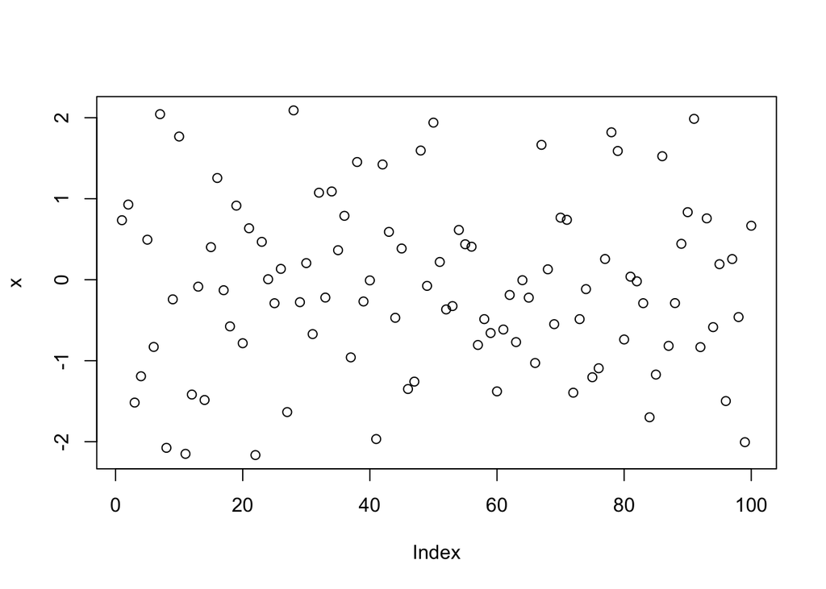

```
| Keep up the great work!

| The 100 random numbers are now plotted in the plots window on the right.

...

| You now learned some basic R commands. We will look into more detail in the next two
| modules of `A (very) short introduction to R`.

...

| You've reached the end of this lesson! Returning to the main menu...
```

```r
plot(x)
```

Module 1 は終了です。

#### 6.4.3 Module 2

つづけて、Module 2 をはじめます。

```
| Please choose a course, or type 0 to exit swirl.

1: A (very) short introduction to R
2: R Programming
3: Take me to the swirl course repository!

Selection: 1

| Please choose a lesson, or type 0 to return to course menu.

1: Module 1
2: Module 2
3: Module 3

Selection: 2
  |                                                                                 |   0%

| Welcome to the second module of 'A (very) short introduction to R'.

...

  |==                                                                               |   2%
| Before you start working, you should set your working directory to where all your data
| and script files are or should be stored. Within RStudio you can go to 'Session'> 'Set
| working directory'. Please do this now.
```

```
> setwd("省略")
```

```
| You are really on a roll!

| R is an interpreter that uses a command line based environment. This means that you have
| to type commands, rather than use the mouse and menus. This has the advantage that you
| do not always have to retype all commands and are less likely to get complaints of arms,
| neck and shoulders.
```

省略

```
| You can store your commands in files, the so-called scripts. These scripts have
| typically file names with the extension .R, e.g. foo.R.

...

| You can open an editor window to edit these files by clicking 'File' and 'New'. Try
| this. Under 'File' you also find the options 'Open file...', 'Save' and 'Save as'.

...

| You can run (send to the console window) part of the code by selecting lines and
| pressing CTRL+ENTER or click 'Run' in the editor window. If you do not select anything,
| R will run the line your cursor is on.

...

| You can always run the whole script with the console command source, so e.g. for the
| script in the file foo.R you type source('foo.R'). You can also click 'Run all' in the
| editor window or type CTRL+SHIFT+S to run the whole script at once.

...

| Make a script called firstscript.R. Type in the script R-code that generates 100 random
| numbers and plots them. Save the script in your working directory (in the folder called
| 'swirl') and type source("firstscript.R") on the command line (here).
```

最初から、working directory を swirl にしておくと簡単です。

**“firstscript.R”** の内容。

```
x = rnorm(100)
plot(x)
```

```
> source("firstscript.R")

| Excellent work!

| Run your script again. The plot will change because new numbers are generated.

> source("firstscript.R")
```

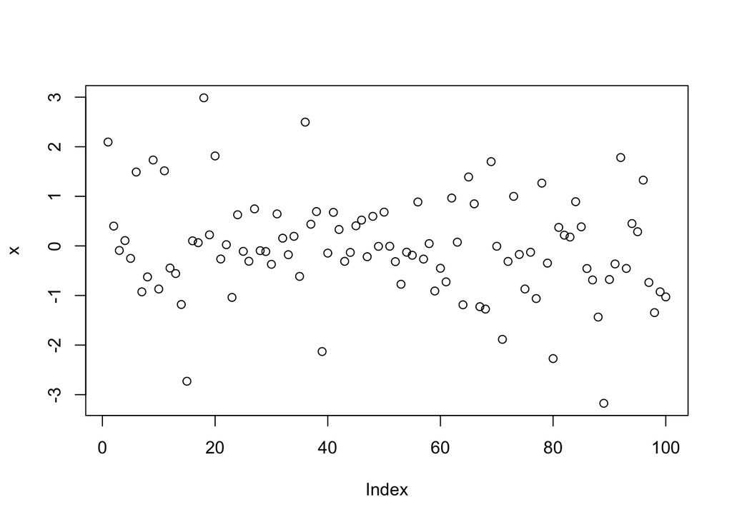

```
| All that practice is paying off!

| Vectors were already introduced, but they can do more. Make a vector with numbers 1, 4,
| 6, 8, 10 and call it vec1.
```

```r
vec1 = c(1,4,6,8,10)
```

```
| Perseverance, that's the answer.

| Elements in vectors can be addressed by standard [i] indexing. Select the 5th element of
| this vector by typing vec1[5].
```

```r
vec1[5]
```

```
## [1] 10
```

```
| You are amazing!

| Replace the 3rd element with a new number by typing vec1[3]=12.
```

```r
vec1[3]=12
```

```
| You got it right!

| Ask R what the new version is of vec1.
```

```r
vec1
```

```
## [1]  1  4 12  8 10
```

```
| That's correct!

| You can also see the numbers of vec1 in the workspace window. Make a new vector vec2
| using the seq() (sequence) function by typing seq(from=0, to=1, by=0.25) and check its
| values in the workspace window.
```

```r
vec2 = seq(from=0, to=1, by=0.25)
```

```
| You are doing so well!

| Type sum(vec1).
```

```r
sum(vec1)
```

```
## [1] 35
```

```
| Excellent job!

| The function sum sums up the elements within a vector, leading to one number (a scalar).
| Now use + to add the two vectors.
```

```r
vec1 + vec2
```

```
## [1]  1.00  4.25 12.50  8.75 11.00
```

```
| Excellent job!

| If you add two vectors of the same length, the first elements of both vectors are
| summed, and the second elements, etc., leading to a new vector of length 5 (just like in
| regular vector calculus).

...

| Matrices are nothing more than 2-dimensional vectors. To define a matrix, use the
| function matrix. Make a matrix with matrix(data=c(9,2,3,4,5,6),ncol=3) and call it mat.
```

```r
mat = matrix(data=c(9,2,3,4,5,6),ncol=3)
```

```
| Keep working like that and you'll get there!

| The argument data specifies which numbers should be in the matrix. Use either ncol to
| specify the number of columns or nrow to specify the number of rows.

...

| Put the numbers 31 to 60 in a vector named P. Use the function seq.
```

```r
P = seq(from = 31, to = 60, by = 1)
```

```
| You got it right!

| Put the numbers 31 to 60 in a matrix named Q with 6 rows and 5 columns.

> Q = matrix(P, nrow = 6, ncol = 5)

| Not quite, but you're learning! Try again. Or, type info() for more options.

| Type ?matrix for information on the function matrix.
```

ここで、つまづきました。

```
Q = matrix(data = P, nrow = 6, ncol = 5)
Q = matrix(data = P, ncol = 5)
Q = matrix(data = seq(from = 31, to = 60, by = 1), nrow = 6, ncol = 5)
Q = matrix(data = seq(from = 31, to = 60, by = 1), ncol = 5)
```

? matrix などで、少し調べ、info() を実行すると

```
> info()

| When you are at the R prompt (>):
| -- Typing skip() allows you to skip the current question.
| -- Typing play() lets you experiment with R on your own; swirl will ignore what you
| do...
| -- UNTIL you type nxt() which will regain swirl's attention.
| -- Typing bye() causes swirl to exit. Your progress will be saved.
| -- Typing main() returns you to swirl's main menu.
| -- Typing info() displays these options again.

> skip()

| Entering the following correct answer for you...
```

```r
Q=matrix(seq(31,60),nrow=6)
```

```
| Great job!
```

結局、これだったようですね。他も、Q は正しく構成されていますが、まったく同じではないと、正解とはなりません。

答えからみると、おそらく正しい問題は、

Put the numbers 31 to 60 in a matrix named Q with 6 rows.

```
| Ask R what Q looks like.
```

```r
Q
```

```
##      [,1] [,2] [,3] [,4] [,5]
## [1,]   31   37   43   49   55
## [2,]   32   38   44   50   56
## [3,]   33   39   45   51   57
## [4,]   34   40   46   52   58
## [5,]   35   41   47   53   59
## [6,]   36   42   48   54   60
```

```
| Nice work!

| You can also click on Q in the workspace window. Look at the different ways scalars,
| vectors and matrices are denoted in the workspace window. Matrix operations are similar
| to vector operations. Elements of a matrix can be addressed in the usual way as
| [row,column]. Select the element on the first row and in the second column of the matrix
| called mat.
```

```r
mat[1,2]
```

```
## [1] 3
```

```
| Excellent work!

| When you want to select a whole row, you leave the spot for the column number empty (the
| other way around for columns of course). Select the second row.
```

```r
mat[2,]
```

```
## [1] 2 4 6
```

```
| You got it!

| Many functions also work with matrices as argument. Compute the mean of mat.
```

```r
mean(mat)
```

```
## [1] 4.833333
```

```
| Your dedication is inspiring!

| The third type of data structure treated here is the data frame. Time series are often
| ordered in data frames. A data frame is a matrix with names above the columns. This is
| nice, because you can call and use one of the columns without knowing in which position
| it is. Make a data frame with t = data.frame(x = c(11,12,14), y = c(19,20,21), z =
| c(10,9,7)).
```

```r
t = data.frame(x = c(11,12,14), y = c(19,20,21), z = c(10,9,7))
```

```
| You are doing so well!

| Ask R what t is.
```

```r
t
```

| x | y | z |
| --- | --- | --- |
| 11 | 19 | 10 |
| 12 | 20 | 9 |
| 14 | 21 | 7 |

```
| Great job!

| The data frame is called t and the columns have the names x, y and z. You can select one
| column by typing t$z. Try this.
```

```r
t$z
```

```
## [1] 10  9  7
```

```
| You are doing so well!

| Another option is to type t[["z"]]. Try this as well.
```

```r
t[["z"]]
```

```
## [1] 10  9  7
```

```
| Excellent job!

| Compute the mean of column z in data frame t.
```

```r
mean(t$z)
```

```
## [1] 8.666667
```

```
| Keep working like that and you'll get there!

| In the following question you will be asked to modify a script that will appear as soon
| as you move on from this question. When you have finished modifying the script, save
| your changes to the script and type submit() and the script will be evaluated. There
| will be some comments in the script that opens up. Be sure to read them!

...

| Make a script file which constructs three random normal vectors of length 100. Call
| these vectors x1, x2 and x3. Make a data frame called t with three columns (called a, b
| and c) containing respectively x1, x1+x2 and x1+x2+x3. Call plot(t) for this data frame.
```

編集ができたら、最後は、submit() です。

**dataframe.R** の編集後の内容

```
# Text behind the #-sign is not evaluated as code by R.
# This is useful, because it allows you to add comments explaining what the script does.

# In this script, replace the ... with the appropriate commands.

x1 = rnorm(100)
x2 = rnorm(100)
x3 = rnorm(100)
t = data.frame(a = x1, b = x1 + x2, c = x1 + x2 + x3)
plot(t)
```

```
> submit()

| Sourcing your script...
```

実行結果

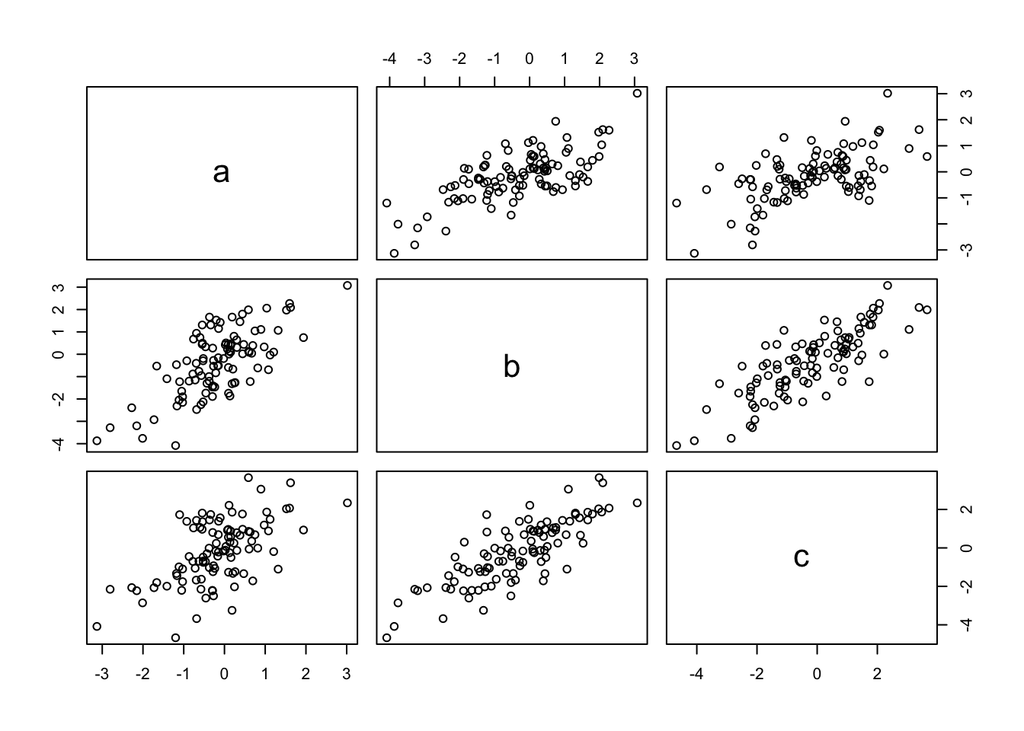

```
| You got it!

| Can you understand the results?

...

| Another basic structure in R is a list. The main advantage of lists is that the
| `columns` (they are not really ordered in columns any more, but are more a collection of
| vectors) don't have to be of the same length, unlike matrices and data frames. Make this
| list L = list(one=1, two=c(1,2), five=seq(0, 1, length=5)).
```

```r
L = list(one=1, two=c(1,2), five=seq(0, 1, length=5))
```

```
| You are really on a roll!

| The list L has names and values. You can type L to see the contents.
```

```r
L
```

```
## $one
## [1] 1
##
## $two
## [1] 1 2
##
## $five
## [1] 0.00 0.25 0.50 0.75 1.00
```

```
| Great job!

| L also appeared in the workspace window. To find out what's in the list, type names(L).
```

```r
names(L)
```

```
## [1] "one"  "two"  "five"
```

```
| Keep working like that and you'll get there!

| Add 10 to the column called five.
```

```r
L$five + 10
```

```
## [1] 10.00 10.25 10.50 10.75 11.00
```

```
| All that practice is paying off!

| Plotting is an important statistical activity. So it should not come as a surprise that
| R has many plotting facilities. Type plot(rnorm(100), type="l", col="gold").
```

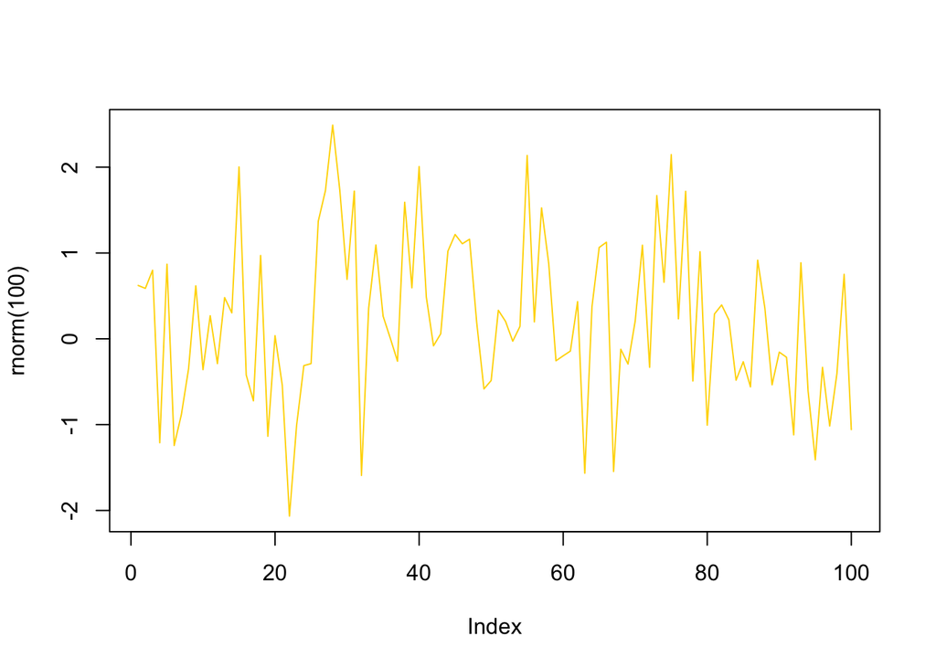

```
| Perseverance, that's the answer.

| Hundred random numbers are plotted by connecting the points by lines in a gold color.

...

| Another very simple example is the classical statistical histogram plot, generated by
| the simple command hist. Make a histogram of 100 random numbers.
```

```r
plot(rnorm(100), type="l", col="gold")
```

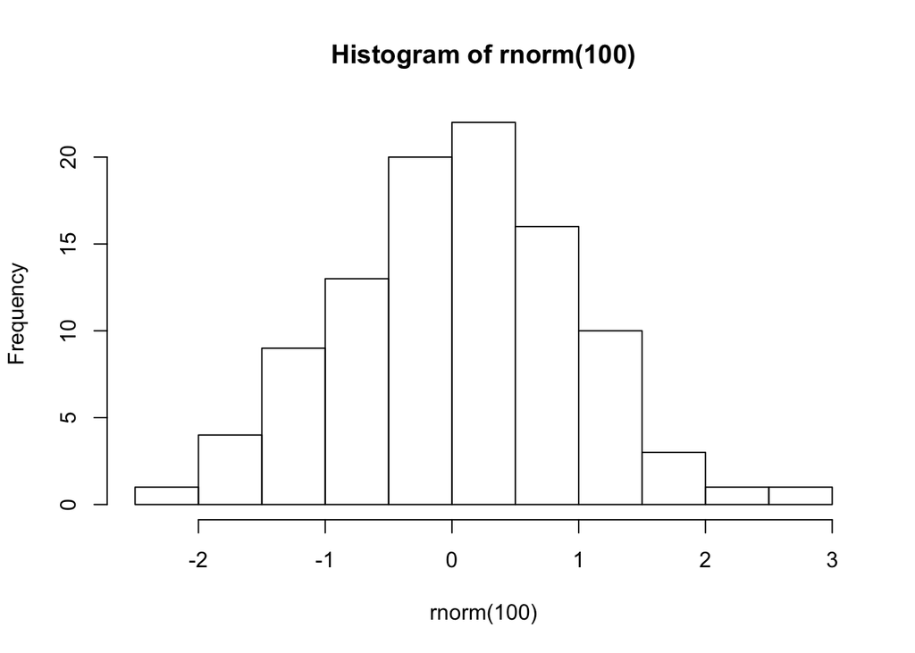

```
| You got it right!

| The script that opens up is the same as the script you made before, but with more
| plotting commands. Type submit() on the command line to run it (you don't have to change
| anything yet).
```

```r
hist(rnorm(100))
```

**plot_dataframe.R** の内容

```
# Text behind the #-sign is not evaluated as code by R.
# This is useful, because it allows you to add comments explaining what the script does.

# Make data frame
x1 = rnorm(100)
x2 = rnorm(100)
x3 = rnorm(100)
t = data.frame(a=x1, b=x1+x2, c=x1+x2+x3)

# Plot data frame
plot(t$a, type='l', ylim=range(t), lwd=3, col=rgb(1,0,0,0.3))
lines(t$b, type='s', lwd=2, col=rgb(0.3,0.4,0.3,0.9))
points(t$c, pch=20, cex=4, col=rgb(0,0,1,0.3))

# Note that with plot you get a new plot window while points and lines add to the previous plot.
```

```
> submit()

| Sourcing your script...
```

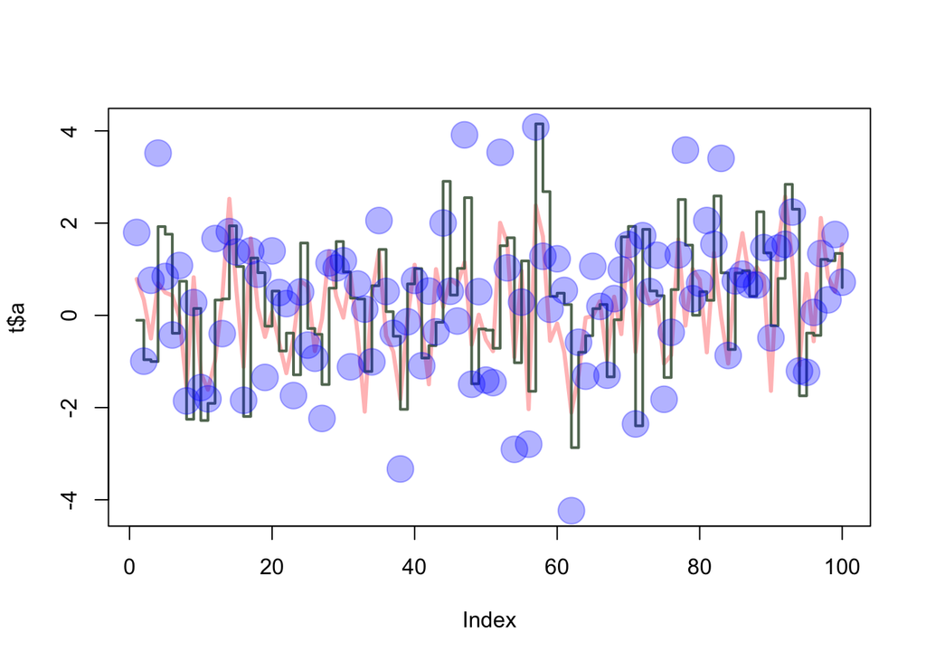

```
| Keep working like that and you'll get there!

| Try to find out by experimenting what the meaning is of rgb, the last argument of rgb,
| lwd, pch, cex. Type play() on the command line to experiment. Modify lines 11, 12 and 13
| of the script by putting your cursor there and pressing CTRL+ENTER. When you are
| finished, type nxt() and then ?par.

> ?par
```

様々な Option を確認してください。

```
| You got it right!

  |===============================================================================  |  98%
| You searched for par in the R help. This is a useful page to learn more about formatting
| plots. Google 'R color chart' for a pdf file with a wealth of color options.

...

  |=================================================================================| 100%
| To copy your plot to a document, go to the plots window, click the 'Export' button,
| choose the nicest width and height and click 'Copy' or 'Save'.

...

| You've reached the end of this lesson! Returning to the main menu...
```

これで、Module 2 の終了です。

#### 6.4.3 Module 3

```
| Please choose a course, or type 0 to exit swirl.

1: A (very) short introduction to R
2: R Programming
3: Take me to the swirl course repository!

Selection: 1

| Please choose a lesson, or type 0 to return to course menu.

1: Module 1
2: Module 2
3: Module 3

Selection: 3
  |                                                                                 |   0%

| Welcome to the third (and last) module of 'A (very) short introduction to R'.

...

  |==                                                                               |   2%
| Before you start working, you should set your working directory to where all your data
| and script files are or should be stored. Within RStudio you can go to 'Tools'> 'Set
| working directory'. Please do this now.

...

  |===                                                                              |   4%
| There are many ways to write data from within the R environment to files, and to read
| data from files. We will illustrate one way here. The following examples illustrate the
| essential.

...

  |=====                                                                            |   6%
| Construct a simple example data frame and store it in the variable d by typing d =
| data.frame(a = c(3,4,5), b = c(12,43,54)) .
```

```r
d = data.frame(a = c(3,4,5), b = c(12,43,54))
```

```
| You got it!

| Ask R what d is.
```

```r
d
```

| a | b |
| --- | --- |
| 3 | 12 |
| 4 | 43 |
| 5 | 54 |

```
| Nice work!

| write this data frame to a text file called tst0.txt by typing write.table(d,
| file="tst0.txt", row.names=FALSE). The argument row.names=FALSE prevents that row names
| are written to the file. Because nothing is specified about col.names, the default
| option col.names=TRUE is chosen and column names are written to the file.

> write.table(d, file="tst0.txt", row.names=FALSE)

| You are amazing!

| The file is now stored in your working directory (the folder ending with swirl). Find it
| on your computer and open the file in an editor (such as Notepad) to see what it looks
| like.

...

| Read the file into a data frame. Type d2 = read.table(file="tst0.txt", header=TRUE).

> d2 = read.table(file="tst0.txt", header=TRUE)

| Your dedication is inspiring!

| Note that the column names are also read (because you specified header=TRUE). The data
| frame also appears in the workspace window. Click on it to see what it looks like.

...

| Make a file called tst1.txt in Notepad from the example in the script that opens up and
| store it in your working directory. Modify the script such that it reads this file,
| multiplies the column called g by 5 and stores it as tst2.txt. Save the script and type
| submit().
```

```
a  g  x
1  2  3
2  4  6
4  8  12
8  16 24
16 32 48
32 64 96
```

**readfiles.R の内容

```
# Make a file called tst1.txt in Notepad with the data below (remove the #-signs) and store it in your working directory.

# a  g  x
# 1  2  3
# 2  4  6
# 4  8  12
# 8  16 24
# 16 32 48
# 32 64 96


# Replace in this script the ... with the appropriate commands.


# Read the file tst1.txt.
d3 = read.table(file="tst1.txt", header = TRUE)


# Multiply the column called g by 5.
d3$g = d3$g*5


# Write the new table to file as tst2.txt.
write.table(d3, file="tst2.txt", row.names=FALSE)
```

```
> submit()

| Sourcing your script...


| You are amazing!

| When you work with real data, you will encounter missing values because instrumentation
| failed or because you didn't want to measure in the weekend. When a data point is not
| available, you write NA instead of a number.

...

| Type j = c(1,2,NA).
```

```r
j = c(1,2,NA)
```

```
| You got it!

| Compute the maximum of this vector j.
```

```r
max(j)
```

```
## [1] NA
```

```
| Great job!

| Computing statistics of incomplete data sets is strictly speaking not possible. Maybe
| the largest value occurred during the weekend when you did not measure. Therefore, R
| will say that it doesn't know what the largest value of j is.

...

| If you don't mind about the missing data and want to compute the statistics anyway, you
| can add the argument na.rm=TRUE. (Should I remove the NAs? Yes!). Try this.
```

```r
max(j, na.rm = TRUE)
```

```
## [1] 2
```

```
| Excellent work!

| The exercises you did before were nearly all with numbers. Sometimes you want to specify
| something which is not a number, for example the name of a measurement station or data
| file. In that case you want the variable to be a character string instead of a number.

...

| An object in R can have several so-called classes. The most important three are numeric,
| character and POSIX (date-time combinations). You can ask R what class a certain
| variable is by typing class(...).

...

| To tell R that something is a character string, you should type the text between
| apostrophes, otherwise R will start looking for a defined variable with the same name.

...

| Define this variable m = "apples" .
```

```r
m = "apples"
```

```
| You got it right!

| Look how the variable m is mentioned in the workspace window. Now try n = pears (so
| without the apostrophes). Look at the error message you get and then type n = "pears".

> n = pears
 エラー:  オブジェクト 'pears' がありません
> n = "pears"

| You got it!

| Of course, you cannot do computations with character strings. Try m+2 . Look at the
| error message you get and type class(m).

> m+2
 m + 2 でエラー:  二項演算子の引数が数値ではありません
```

```r
class(m)
```

```
## [1] "character"
```

```
| Great job!

| Dates and times are complicated. R has to know that 3 o'clock comes after 2:59 and that
| February has 29 days in some years. The easiest way to tell R that something is a
| date-time combination is with the function strptime.

...

| Create a vector of dates by typing (or copy-pasting) date1 = strptime(
| c("20170225230000", "20170226000000", "20170226010000"), format="%Y%m%d%H%M%S") .
```

```r
date1 = strptime(c("20170225230000", "20170226000000", "20170226010000"), format="%Y%m%d%H%M%S")
```

```
| All that hard work is paying off!

| The numbers in the vectors are between apostrophes because the function strptime needs
| character strings as input. The argument format specifies how the character string
| should be read. In this case the year is denoted first (%Y), then the month (%m), day
| (%d), hour (%H), minute (%M) and second (%S). You don't have to specify all of them, as
| long as the format corresponds to the character string.

...

| Ask R what date1 is. Also see how date1 appears in the workspace window.
```

```r
date1
```

```
## [1] "2017-02-25 23:00:00 JST" "2017-02-26 00:00:00 JST"
## [3] "2017-02-26 01:00:00 JST"
```

```
| All that practice is paying off!

| Make a graph with on the x-axis today, Sinterklaas 2017 and your next birthday and on
| the y-axis the number of presents you expect on each of these days. Type this in the
| script, save it and type submit().
```

**plotdates.R** の編集後の内容（個人によってことなります。）

```
# Replace in this script the ... with the appropriate commands.

# Make a vector called dates with the three dates:
# today, Sinterklaas (a Dutch holiday) and your next birthday.
dates = strptime(c("20200505","20201205", "20210401"), format="%Y%m%d")

# Make a vector called presents with the three expected number of presents.
presents = c(1, 3, 2)

# Plot the dates versus the number of presents.
plot(dates, presents)
```

```
> submit()

| Sourcing your script...
```

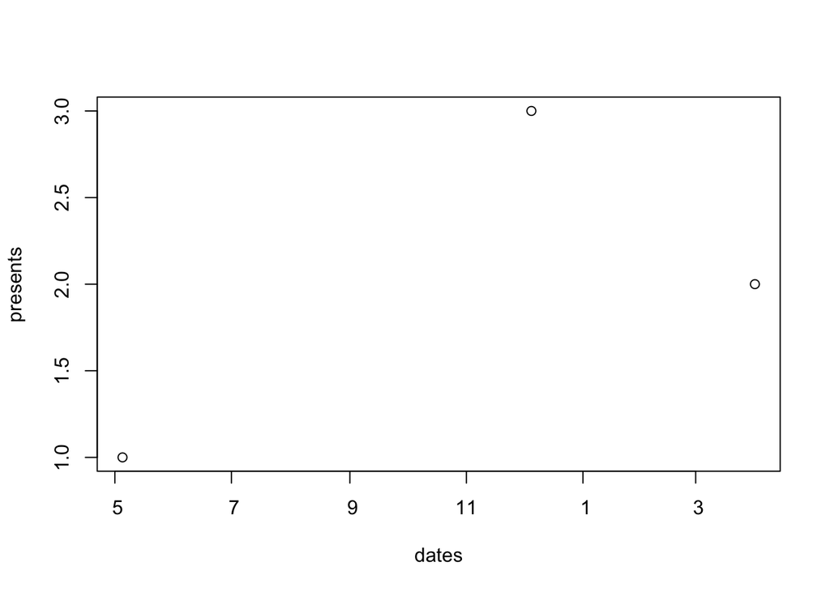

```
| All that practice is paying off!

| When you are building a larger program than in the examples above or if you are using
| someone else's scripts, you may encounter some programming statements. In the second
| half of this module we describe a few tips and tricks.

...

| The if-statement is used when certain computations should only be done when a certain
| condition is met (and maybe something else should be done when the condition is not
| met).

...

| The script that opens up contains an if statement. Read it (you don't have to change
| anything) and type submit() to execute the script.
```

下のスクリプトを編集する必要はありません。

**ifstatement.R**

```
# define a variable called w
w = 3

if(w < 5){
  d=2
}else{
  d=10
}

# First a condition is specified: w should be less than 5.
# If the condition is met, R will execute what is between the first brackets.
# If the condition is not met, R will execute what is between the second brackets, after the else.
# You can leave the else{...}-part out if you don't need it.
```

```
> submit()

| Sourcing your script...
```

```
| You are really on a roll!

| Ask what d is.
```

```r
d
```

```
## [1] 2
```

```
| You nailed it! Good job!

| In this case, the condition is met and d has been assigned the value 2.

...

| To get a subset of points in a vector for which a certain condition holds, you can use a
| shorter method. Make one vector with a = c(1,2,3,4) .
```

```r
a = c(1,2,3,4)
```

```
| Excellent work!

| Make another vector with b = c(5,6,7,8) .
```

```r
b = c(5,6,7,8)
```

```
| All that hard work is paying off!

| Now type f = a[b==5 | b==8]
```

```r
f = a[b==5 | b==8]
```

```
| That's a job well done!

| And ask what f is.
```

```r
f
```

```
## [1] 1 4
```

```
| Nice work!

| The vector f is composed of those elements of vector a for which b equals 5 or b equals
| 8.

...

| Note the double = in the condition. Other conditions (also called logical or Boolean
| operators) are <, >, != (not equal to), <= (less than or equal to) and >= (greater than
| or equal to).

...

| To test more than one condition in one if-statement, use & if both conditions have to be
| met ('and') and | if at least one of the conditions has to be met ('or').

...

| If you want to model a time series, you usually do the computations for one time step
| and then for the next and the next, etc. Because nobody wants to type the same commands
| over and over again, these computations are automated in for-loops.

...

| In a for-loop you specify what has to be done and how many times. To tell how many
| times, you specify a so-called counter.

...

| The script that opens up contains a for-loop. Read it (you don't have to change
| anything) and type submit() to execute the script.
```

編集する必要はありません。

**forloop.R** の内容

```
# Define a vector called h.

h = seq(from=1, to=8)


# Create an empty vector called s.
# This is necessary because when you introduce a variable within the for-loop,
# R will not remember it when it has gotten out of the for-loop.

s = c()


# The next lines contain the for-loop.
# In this case, i is the counter and runs from 2 to 10.
# Everything between the curly brackets is processed 9 times.
# The first time i=2, the second element of h is multiplied with 10
# and placed in the second position of the vector s.
# The second time i=3, etc.
# In the last two runs, the 9th and 10th elements of h are requested, which do not exist.
# Note that these statements are evaluated without any explicit error messages.

for(i in 2:10)
{
  s[i] = h[i] * 10
}
```

```
> submit()

| Sourcing your script...


| Perseverance, that's the answer.

| Make a vector called z containing numbers from 1 to 100 in the script that opens up.
| Make a for-loop which runs through the whole vector. Within the for-loop, multiply the
| elements which are smaller than 5 or larger than 90 with 10 and the other elements with
| 0.1.
```

**exercise_forloop.R** の内容

```
# Replace the ... with the appropriate commands.

# Make vector called z containing numbers from 1 to 100.
z = seq(1,100)

# Make the for-loop with the range to run over in round brackets,
# the things to do each run in curly brackets,
# and an if-statement between the curly brackets.

for(i in z)
{
  if(z[i] < 5 | z[i] > 90){
    z[i] = z[i] * 10
  }else{
    z[i] = z[i] * 0.1
  }
}
```

```
> submit()

| Sourcing your script...


| Your dedication is inspiring!

| You can also program functions yourself. These work in the same way as pre-programmed R
| functions.

...

| The script that opens up contains an example of a self-programmed function. Read it (you
| don't have to change anything) and type submit() to execute the script.
```

編集する必要はありません。

**function.R** の内容

```r
fun1 = function(arg1, arg2)
{
  w = arg1 ^ 2
  return(arg2 + w)
}

# In line 1 the function name (fun1) and its arguments (arg1 and arg2) are defined.
# Lines 2-5 specify what the function should do if it is called.
# The return value (arg2+w) is given as output.
```

```
> submit()

| Sourcing your script...


| All that hard work is paying off!

| You can see that the function appeared in your workspace window (you may have to scroll
| down). To call the function with arguments 3 and 5, type fun1(arg1 = 3, arg2 = 5) .
```

```r
fun1(arg1 = 3, arg2 = 5)
```

```
## [1] 14
```

```
| Excellent work!

| Try to understand the answer you get. When you call the function, R fills out the value
| 3 for each occurrence of arg1 and 5 for arg2.

...

| Write a function (called fun2) for the previous exercise, so that you can feed it any
| vector you like (as argument). Use a for-loop in the function to do the computation with
| each element. Use the standard R function length in the specification of the counter.
```

**exercise_function.R** わたしの入力（間違っています！）

```
# Put the for-loop you made before inside a function.
# Use the same structure as fun1,
# so copy and modify the first and last lines of this script.
# Call your new function fun2, with one argument called z.


fun2 = function(z)
{
  for(i in 1:length(z))
  {
    if(z[i] < 5 | z[i] > 90){
      z[i] = z[i] * 10
    }else{
      z[i] = z[i] * 0.1
    }
  }
}
```

```
> submit()

| Sourcing your script...


| Not quite, but you're learning! Try again.

> skip()

| I just sourced the following script, which demonstrates one possible solution.
```

**exercise_function_correct.R** 正解

```
# Put the for-loop you made before inside a function.
# Use the same structure as fun1,
# so copy and modify the first and last lines of this script.
# Call your new function fun2, with one argument called z.

fun2 = function(z)
{
  for(i in 1:length(z))
  {
    if(z[i] < 5 | z[i] > 90){
      z[i] = z[i] * 10
    }else{
      z[i] = z[i] * 0.1
    }
  }
  return(z)
}
```

```
Press Enter when you are ready to continue...

| Keep up the great work!

| Actually, people often use more for-loops than necessary. The previous exercise can be
| done more easily and quickly without a for-loop but with regular vector computations.

...

| You finished 'A (very) short introduction to R'. You can use the pdf version of this
| short course as a reference. The last two pages of that document also contains a list of
| useful commands that you can use as inspiration for your programming.

...

| You've reached the end of this lesson! Returning to the main menu...

| Please choose a course, or type 0 to exit swirl.

1: A (very) short introduction to R
2: R Programming
3: Take me to the swirl course repository!

Selection: 0

| Leaving swirl now. Type swirl() to resume.

>
```